# Principios y Prácticas de SEM y MLM (5ed)

Tema 1.2 Modelos de Regresión Lineal

Author

Efraín García Sánchez

Published

August 5, 2026

# Definiciones

## ¿Que es un modelo de regresión lineal?

- Modelo lineal a través del cual se estima los valores de una variable resultado, a partir de unas variables predictoras
  - x<sub>i</sub> = variable predictora
  - b<sub>0</sub> = valor del resultado cuando X es cero
  - b<sub>1</sub> = magnitud de la relación
- Tres componentes
  - Intercepto + Pendiente + Error

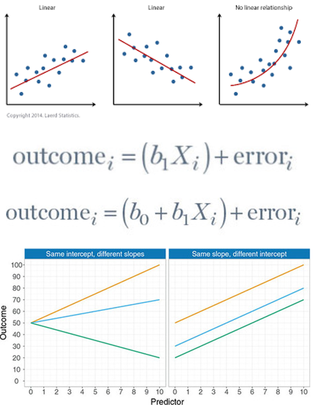

## ¿Qué representan los modelos de regresión lineal?

- Regresiones:
  - Simples: un solo predictor
  - Múltiples: varios predictores
  - Univariadas: Una sola variable resultado
  - Multivariadas: Más de una variable resultado
- Representa:
  - Relaciones entre variables (manteniendo constante otras variables)

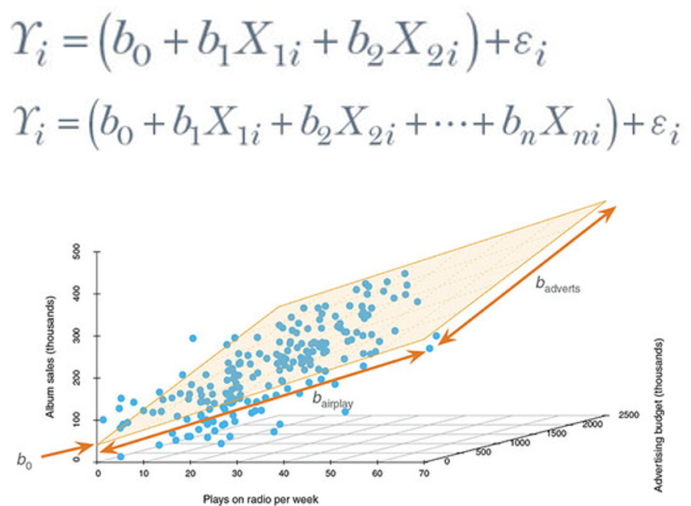

## Representación visual de la regresión

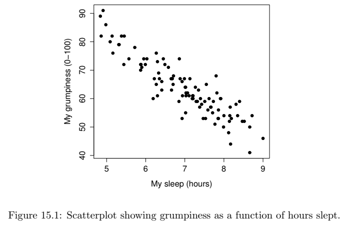

Figure 1: Datos brutos

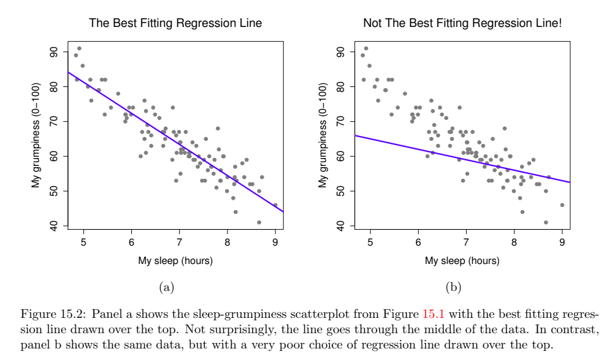

Líneas de regresión

Fuente: [Navarro (2019). Learning statistics with R](https://learningstatisticswithr.com/)

## Regresiones y causalidad

- Causalidad
  - No en la técnica estadística
  - Sí en el diseño, plausibilidad teórica, orden temporal…
- Regresión
  - Son correlaciones, no prueba causalidad
  - Pero ayuda con el **control estadístico** de variables
    - Remueve el efecto de W en X –> Y
    - Controlar por W<sub>1</sub> y por W<sub>2</sub>
    - Mantiene W<sub>1,2</sub> constante (no varía)
    - El efecto único e independiente de X sobre Y
    - Eliminar el efecto de W sobre X–>Y

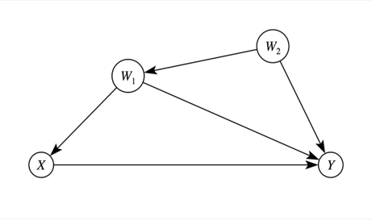

# Principios

## Componentes de los modelos de regresión lineal

- Componentes:
  - La pendiente es el modelo lineal (estimación)
  - Puntos azules son los valores observados
  - La distancia entre los puntos azules y la pendiente son los residuos (*deviation*)
- Ordinary Least Squares (OLS):
  - Encuentra el modelo que minimiza la suma de los errores
  - El error total es la suma de todos los errores del modelo (*residual sum of squares SSR*)
    - Si es **muy grande**: el modelo no se ajusta bien (y viceversa)

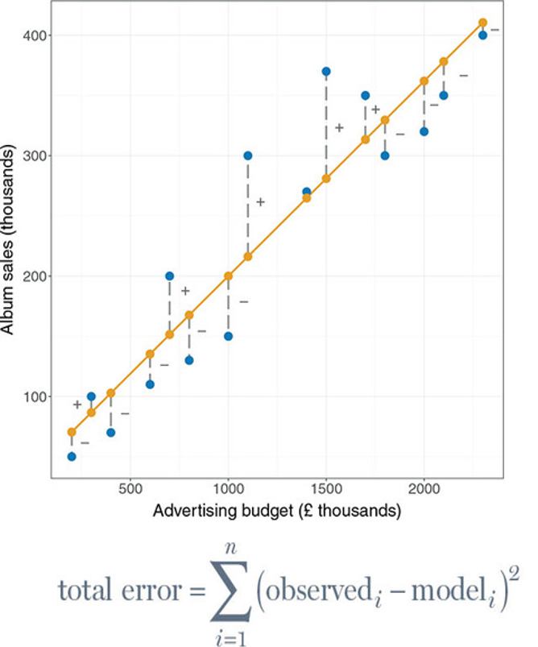

## Ordinary Least squares Method

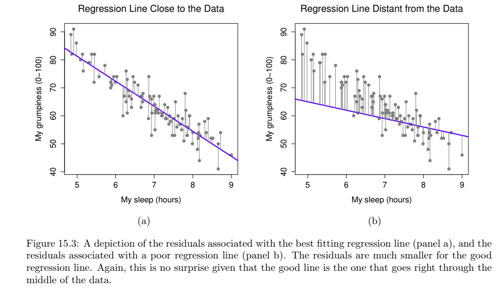

Fuente: [Navarro (2019). Learning statistics with R](https://learningstatisticswithr.com/)

## Bondad de ajuste, suma de cuadrados y R<sup>2</sup>

- Compara el modelo estimado (lineal) con un modelo de base (media)

  La mejoría de ajuste del *modelo lineal* sobre el *modelo base* (*Sum of squares for Model* SSM)
  - Si es **grande**: buen ajuste, es mejor que el modelo base
  - Si es **pequeño**: mal ajuste, es peor que el modelo base
- La proporción de mejoría de ajuste según el modelo es *R<sup>2</sup>* (varianza explicada)

$$R^2 = \frac{SS_M}{SS_T} = \frac{SumSquares_{Model}}{SumSquares_{Total}}$$

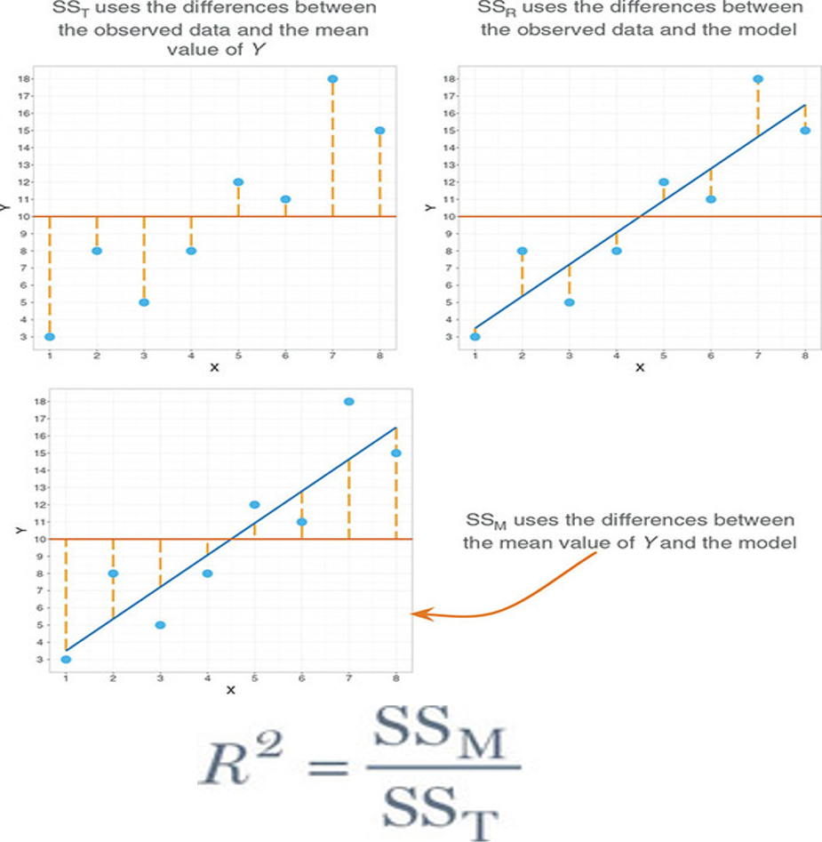

## La bondad de ajuste del modelo

- El estadístico F
  - Cantidad en la que el modelo ha mejorado la predicción de la variable resultado, comparado con el nivel de error del modelo.
  - F’s grandes, indican mejor ajuste
  - Indica si el modelo es estadísticamente significativo (diferente de un modelo nulo (*H<sub>0</sub>*).
- Prueba del modelo general:
  - Adicionar predictores mejora la predicción
  - ¿cuál predictor y en qué sentido?

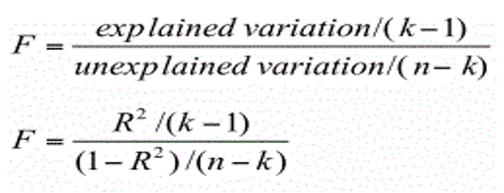

## Variables predictoras

- Muchos términos
  - Criterio, independiente, exógena, predictora, etc.
- Predictores tienen un coeficiente *b* ($\beta$ o $\B$)
  - Representan el cambio esperado en la variable resultado (*Y*) por cada cambio en una (1) unidad de la variable predictora (X<sub>i</sub>)
    - $\beta = 0$ NO hay cambio
    - $\beta = 1$ Se espera un aumento de 1 en Y, por cada cambio en 1 unidad de X
- ¿cómo determinar si el predictor es estadísticamente significativo?
  - Estadístico *t* (Null Hyphotesis Significance Testing (NHST))

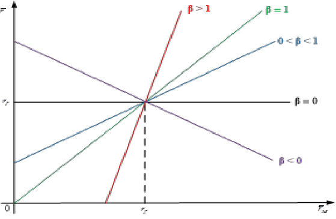

## Supuestos estadísticos

- Linealidad: Los parámetros deben reflejar relaciones lineales
  - No se cumple: cambiar el modelo (e.g. logit, probit, etc.)
- Aditividad: los predictores sumados deben mejorar la predicción
  - No se cumple: Re-especificar el modelo
- Normalidad: Los residuos están normalmente distribuidos
  - No se cumple: Probar tests robustos (e.g., Bootstrapping)
- Residuos independientes: Los residuos **NO** deben estar relacionados
  - No se cumple: Controlar por los errores (e.g., MLM)

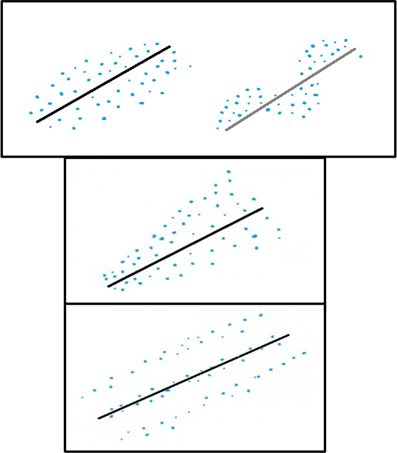

## Supuestos prácticos

- Homocedasticidad (*Homogeneity of variance*): La varianza de los residuos debe ser constante a diferentes niveles de los predictores
  - No se cumple: Test robustos u otros estimadores (e.g., WLS, RSE)
- Predictores independientes: Recomendación práctica, no un supuesto
  - No se cumple: Verificar las correlaciones y el VIF
- Sensible a casos individuales
  - Outliers: Pocos valores que desajustan el modelo
  - Casos de influencia: Afectan la estabilidad del modelo
  - Verificar: Adjusted predicted values, Deleted residual y Studentized deleted residual, Distancia de Cook (evitar valores >1), Distancia de Mahalanobis, Leverage, etc.

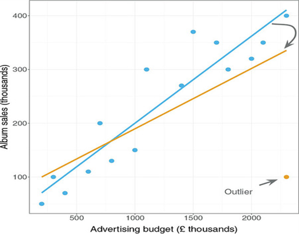

## Tamaño de la muestra

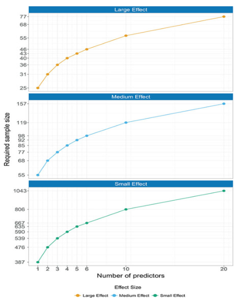

Source: Fields (2018)

## En resumen

- Regresiones múltiples son una herramienta matemática para determinar la asociación entre dos variables, manteniendo constantes otras variables predictoras
- Cuantifica la asociación entre dos variables
- Equiparar a las personas en las variables de control
- Covariables ayudan a controlar por explicaciones alternativas
- Interpretación:

“*b* es la diferencia estimada en Y entre dos casos A y B que difieren en una unidad de X, siendo iguales en todas las variables antecedentes, excepto en X.”

# Práctica

## Preparar el ambiente de trabajo

```r
# instalar los paquetes
# install.packages("tidyverse")
# install.packages("car")
# install.packages("sjPlot")
# install.packages("sjmisc")

# Cargar los paquetes
library(tidyverse)
library(car)
library(sjPlot)
library(sjmisc)
```

## Importar los datos

```r
data <- haven::read_sav(
  here::here("..", "data",
             "northampton_student_health_data_package",
             "northampton_student_health_labelled.sav"))

glimpse(data)
```

```
Rows: 590
Columns: 61
$ id                             <dbl> 1, 2, 3, 4, 5, 6, 7, 8, 9, 10, 11, 12, …
$ age_group                      <dbl+lbl> 1, 1, 1, 1, 1, 1, 2, 4, 1, 1, 1, 1,…
$ gender                         <dbl+lbl> 2, 1, 1, 1, 1, 2, 1, 1, 2, 2, 2, 2,…
$ sexual_orientation             <dbl+lbl> 1, 2, 1, 3, 1, 1, 1, 1, 1, 1, 1, 1,…
$ ethnicity                      <dbl+lbl> 1, 1, 1, 2, 1, 3, 1, 1, 1, 3, 1, 1,…
$ study_mode                     <dbl+lbl> 1, 1, 1, 1, 1, 1, 1, 2, 1, 1, 1, 1,…
$ study_level                    <dbl+lbl> 3, 3, 3, 3, 2, 6, 4, 3, 1, 2, 1, 1,…
$ living_situation               <dbl+lbl> 1, 2, 1, 3, 2, 4, 3, 3, 1, 2, 4, 1,…
$ phys_health                    <dbl+lbl> 3, 4, 4, 3, 4, 5, 5, 1, 4, 4, 4, 5,…
$ ment_health                    <dbl+lbl> 4, 3, 2, 4, 3, 3, 2, 1, 4, 4, 3, 5,…
$ social_connect                 <dbl+lbl> 4, 3, 1, 1, 2, 3, 2, 4, 4, 3, 3, 3,…
$ sitting_weekday_hours          <dbl> 8, 5, 7, 9, NA, 5, 11, 13, 6, 5, 12, 6,…
$ sleep_quality                  <dbl> 8, 7, 4, 7, 2, 5, 3, 8, 7, 2, 9, 7, 3, …
```

[output cut: 48 more lines]

## Pregunta de Investigación y Variables

### ¿cómo se asocia la actividad física y el consumo de alcohol con la salud mental auto-reportada?

```r
ment_health       # "In general, how would you rate your mental health?"
pa_activity_level # "how many days 30 minutes or more of physical activity?"
alcohol_freq      # "How often do you have a drink containing alcohol?"
```

## Explorar los datos: `psych::describe()`

```r
data |>
  select(ment_health, pa_activity_level, alcohol_freq, gender, age_group, ethnicity) |>
  psych::describe()
```

```
                  vars   n mean   sd median trimmed  mad min max range  skew
ment_health          1 590 3.45 1.05      4    3.49 1.48   1   5     4 -0.38
pa_activity_level    2 590 1.18 0.60      1    1.22 0.00   0   2     2 -0.09
alcohol_freq         3 590 1.48 1.70      1    1.24 1.48   0   7     7  0.94
gender               4 590 1.36 0.55      1    1.28 0.00   1   4     3  1.45
age_group            5 590 1.74 0.91      2    1.59 1.48   1   6     5  1.28
ethnicity            6 590 2.65 1.68      3    2.54 1.48   1  13    12  1.82
                  kurtosis   se
ment_health          -0.40 0.04
pa_activity_level    -0.40 0.02
alcohol_freq         -0.29 0.07
gender                2.10 0.02
age_group             1.46 0.04
ethnicity             7.87 0.07
```

## Preparar los datos `data wrangling`

- Transformar y recodificar variables

```r
data <- data |>
  mutate(# creo variable dummy para género (Female vs Male)
         gender_female = case_when(gender == 1 ~ 1, # Female
                                   gender == 2 ~ 0, # Male
                                   .default = NULL),
         # creo una variable de etnia para los grupos más grandes
         ethnicity_cat = case_when(ethnicity == 1 ~ "White",
                                 ethnicity == 3 ~ "Black",
                                 ethnicity == 4 ~ "Asian",
                                 TRUE ~ NA_character_),
         # ordeno la variable de etnia en niveles (White es la referencia)
         ethnicity_cat = factor(ethnicity_cat,
                                levels = c("White", "Black", "Asian")),
         # Creo una variable dummy para ver diferencias con White
         ethnicity_black = ifelse(test = ethnicity_cat == "Black",
                                  yes = 1, no = 0),
         ethnicity_asian = ifelse(test = ethnicity_cat == "Asian",
                                  yes = 1, no = 0))
```

## Verificar que ha salido bien

```r
data |>
  select(gender, gender_female,
         ethnicity, ethnicity_cat,
         ethnicity_black, ethnicity_asian) |>
  tail(n = 10)
```

```
# A tibble: 10 × 6
   gender  gender_female ethnicity ethnicity_cat ethnicity_black ethnicity_asian
   <dbl+l>         <dbl> <dbl+lbl> <fct>                   <dbl>           <dbl>
 1 1 [Fem…             1 1 [White] White                       0               0
 2 1 [Fem…             1 1 [White] White                       0               0
 3 1 [Fem…             1 4 [Asian… Asian                       0               1
 4 1 [Fem…             1 1 [White] White                       0               0
 5 1 [Fem…             1 3 [Black… Black                       1               0
 6 2 [Mal…             0 4 [Asian… Asian                       0               1
 7 1 [Fem…             1 1 [White] White                       0               0
 8 2 [Mal…             0 4 [Asian… Asian                       0               1
 9 1 [Fem…             1 1 [White] White                       0               0
10 2 [Mal…             0 3 [Black… Black                       1               0
```

## Explorar los datos: correlaciones

```r
data |>
    dplyr::select(ment_health, pa_activity_level, alcohol_freq) |>
  correlation::correlation()
```

```
# Correlation Matrix (pearson-method)

Parameter1        |        Parameter2 |     r |         95% CI | t(588) |       p
---------------------------------------------------------------------------------
ment_health       | pa_activity_level |  0.09 | [ 0.01,  0.17] |   2.27 | 0.048*
ment_health       |      alcohol_freq | -0.13 | [-0.21, -0.05] |  -3.22 | 0.004**
pa_activity_level |      alcohol_freq |  0.08 | [ 0.00,  0.16] |   1.93 | 0.054

p-value adjustment method: Holm (1979)
Observations: 590
```

## Explorar los datos: correlaciones (+ distribuciones)

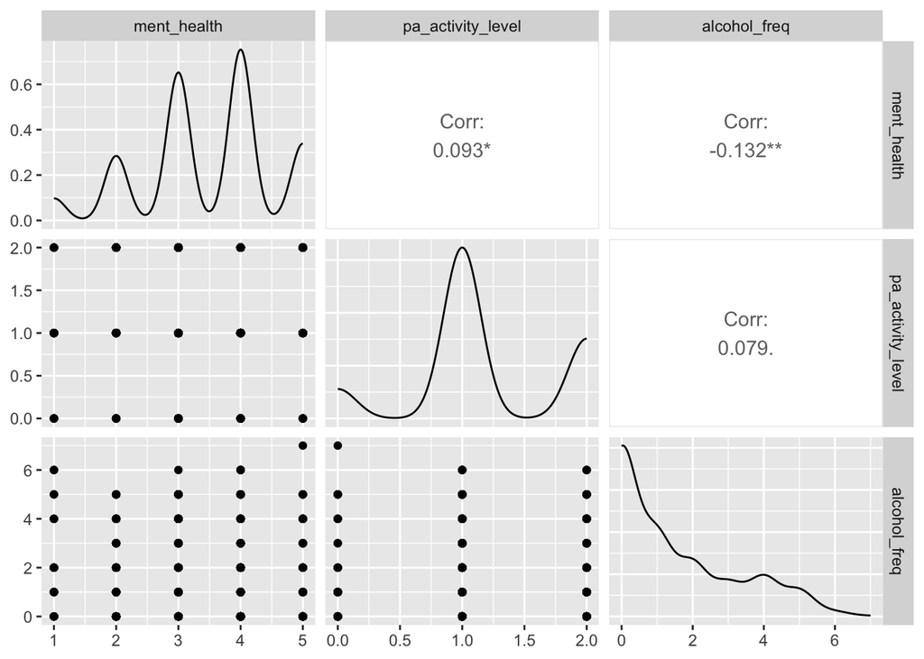

```r
data |>
  select(ment_health, pa_activity_level, alcohol_freq) |>
  GGally::ggpairs()
```

## Modelo de Regresión: El intercepto

```r
m0 <- lm(formula =  ment_health ~ 1,
         data = data)
```

```r
summary(m0)
```

```
Call:
lm(formula = ment_health ~ 1, data = data)

Residuals:
    Min      1Q  Median      3Q     Max
-2.4475 -0.4475  0.5525  0.5525  1.5525

Coefficients:
            Estimate Std. Error t value Pr(>|t|)
(Intercept)  3.44746    0.04338   79.48   <2e-16 ***
---
Signif. codes:  0 '***' 0.001 '**' 0.01 '*' 0.05 '.' 0.1 ' ' 1

Residual standard error: 1.054 on 589 degrees of freedom
```

```r
mean(data$ment_health, na.rm = TRUE)
```

```
[1] 3.447458
```

## Regresión Simple (un único predictor)

```r
m1 <- lm(ment_health ~ pa_activity_level, data = data)
```

```r
parameters::parameters(m1)
```

```
Parameter         | Coefficient |   SE |       95% CI | t(588) |      p
-----------------------------------------------------------------------
(Intercept)       |        3.25 | 0.10 | [3.07, 3.44] |  34.04 | < .001
pa activity level |        0.16 | 0.07 | [0.02, 0.31] |   2.27 | 0.024
```

## Regresión Simple (un único predictor: estandarizada)

```r
parameters::standardize_parameters(m1)
```

```
# Standardization method: refit

Parameter         | Std. Coef. |        95% CI
----------------------------------------------
(Intercept)       |   8.02e-16 | [-0.08, 0.08]
pa activity level |       0.09 | [ 0.01, 0.17]
```

```r
data |>
  select(ment_health, pa_activity_level) |>
  cor() |>
  round(digits = 2)
```

```
                  ment_health pa_activity_level
ment_health              1.00              0.09
pa_activity_level        0.09              1.00
```

## Regresión Múltiple (más de un predictor)

```r
m2 <- lm(ment_health ~ pa_activity_level + alcohol_freq,
              data = data)

parameters::parameters(m2)
```

```
Parameter         | Coefficient |   SE |         95% CI | t(587) |      p
-------------------------------------------------------------------------
(Intercept)       |        3.36 | 0.10 | [ 3.16,  3.56] |  33.72 | < .001
pa activity level |        0.18 | 0.07 | [ 0.04,  0.32] |   2.55 | 0.011
alcohol freq      |       -0.09 | 0.03 | [-0.14, -0.04] |  -3.43 | < .001
```

## Regresión Múltiple (más de un predictor)

```r
m2 <- lm(ment_health ~ pa_activity_level + alcohol_freq,
              data = data)

summary(m2)
```

```
Call:
lm(formula = ment_health ~ pa_activity_level + alcohol_freq,
    data = data)

Residuals:
    Min      1Q  Median      3Q     Max
-2.5533 -0.5431  0.2735  0.6403  2.2466

Coefficients:
                  Estimate Std. Error t value Pr(>|t|)
(Intercept)        3.35968    0.09962  33.723  < 2e-16 ***
pa_activity_level  0.18342    0.07186   2.552 0.010953 *
alcohol_freq      -0.08661    0.02528  -3.427 0.000654 ***
---
Signif. codes:  0 '***' 0.001 '**' 0.01 '*' 0.05 '.' 0.1 ' ' 1

Residual standard error: 1.04 on 587 degrees of freedom
Multiple R-squared:  0.02811,   Adjusted R-squared:  0.02479
F-statistic: 8.488 on 2 and 587 DF,  p-value: 0.0002324
```

## Regresión Múltiple (+ covariables)

```r
m3 <- lm(ment_health ~ pa_activity_level + alcohol_freq + age_group + gender_female,
              data = data)

parameters::parameters(m3)
```

```
Parameter         | Coefficient |   SE |         95% CI | t(568) |      p
-------------------------------------------------------------------------
(Intercept)       |        3.09 | 0.14 | [ 2.82,  3.37] |  22.12 | < .001
pa activity level |        0.24 | 0.07 | [ 0.11,  0.37] |   3.53 | < .001
alcohol freq      |       -0.07 | 0.02 | [-0.12, -0.03] |  -3.12 | 0.002
age group         |        0.30 | 0.04 | [ 0.21,  0.39] |   6.69 | < .001
gender female     |       -0.43 | 0.09 | [-0.60, -0.25] |  -4.84 | < .001
```

## Comparar el desempeño de los modelos

```r
performance::compare_performance(m0, m1, m2, m3)
```

```
# Comparison of Model Performance Indices

Name | Model |  AIC (weights) | AICc (weights) |  BIC (weights) |    R2
-----------------------------------------------------------------------
m0   |    lm | 1739.0 (<.001) | 1739.0 (<.001) | 1747.8 (<.001) | 0.000
m1   |    lm | 1735.9 (<.001) | 1735.9 (<.001) | 1749.0 (<.001) | 0.009
m2   |    lm | 1726.2 (<.001) | 1726.2 (<.001) | 1743.7 (<.001) | 0.028
m3   |    lm | 1593.8 (>.999) | 1594.0 (>.999) | 1619.9 (>.999) | 0.135

Name | R2 (adj.) |  RMSE | Sigma
--------------------------------
m0   |     0.000 | 1.053 | 1.054
m1   |     0.007 | 1.048 | 1.050
m2   |     0.025 | 1.038 | 1.040
m3   |     0.129 | 0.962 | 0.966
```

## Comparar los parámeteros de los modelos

```r
parameters::compare_parameters(m0, m1, m2, m3)
```

```
Parameter         |                m0 |                m1
---------------------------------------------------------
(Intercept)       | 3.45 (3.36, 3.53) | 3.25 (3.07, 3.44)
pa activity level |                   | 0.16 (0.02, 0.31)
alcohol freq      |                   |
age group         |                   |
gender female     |                   |
---------------------------------------------------------
Observations      |               590 |               590

Parameter         |                   m2 |                   m3
---------------------------------------------------------------
(Intercept)       |  3.36 ( 3.16,  3.56) |  3.09 ( 2.82,  3.37)
pa activity level |  0.18 ( 0.04,  0.32) |  0.24 ( 0.11,  0.37)
alcohol freq      | -0.09 (-0.14, -0.04) | -0.07 (-0.12, -0.03)
age group         |                      |  0.30 ( 0.21,  0.39)
gender female     |                      | -0.43 (-0.60, -0.25)
---------------------------------------------------------------
Observations      |                  590 |                  573
```

## Comparar modelos (parámetros y rendimiento) `sjPlot::tab_model()`

```r
sjPlot::tab_model(m0, m1, m2, m3)
```

|  | In general,how would you rate your mental health? |  |  | In general,how would you rate your mental health? |  |  | In general,how would you rate your mental health? |  |  | In general,how would you rate your mental health? |  |  |
| --- | --- | --- | --- | --- | --- | --- | --- | --- | --- | --- | --- | --- |
| Predictors | Estimates | CI | p | Estimates | CI | p | Estimates | CI | p | Estimates | CI | p |
| (Intercept) | 3.45 | 3.36 – 3.53 | **<0.001** | 3.25 | 3.07 – 3.44 | **<0.001** | 3.36 | 3.16 – 3.56 | **<0.001** | 3.09 | 2.82 – 3.37 | **<0.001** |
| On a typical week,on how many days have you done a total of 30 minutes or more of physical activity? |  |  |  | 0.16 | 0.02 – 0.31 | **0.024** | 0.18 | 0.04 – 0.32 | **0.011** | 0.24 | 0.11 – 0.37 | **<0.001** |
| How often do you have a drink containing alcohol? |  |  |  |  |  |  | -0.09 | -0.14 – -0.04 | **0.001** | -0.07 | -0.12 – -0.03 | **0.002** |
| What is your age? |  |  |  |  |  |  |  |  |  | 0.30 | 0.21 – 0.39 | **<0.001** |
| gender female |  |  |  |  |  |  |  |  |  | -0.43 | -0.60 – -0.25 | **<0.001** |
| Observations | 590 |  |  | 590 |  |  | 590 |  |  | 573 |  |  |
| R<sup>2</sup> / R<sup>2</sup> adjusted | 0.000 / 0.000 |  |  | 0.009 / 0.007 |  |  | 0.028 / 0.025 |  |  | 0.135 / 0.129 |  |  |

## Comparar modelos (parámetros y rendimiento) `sjPlot::tab_model()`

```r
sjPlot::tab_model(m0, m1, m2, m3,
                  dv.labels = c("M0. (intercepto)",
                                "M1. (PA activity)",
                                "M2. (+alcohol)",
                                "M3. (demographics)"),
                  show.ci = FALSE,
                  show.aicc = TRUE,
                  show.aic = TRUE,
                  auto.label = FALSE)
```

|  | M0. (intercepto) |  | M1. (PA activity) |  | M2. (+alcohol) |  | M3. (demographics) |  |
| --- | --- | --- | --- | --- | --- | --- | --- | --- |
| Predictors | Estimates | p | Estimates | p | Estimates | p | Estimates | p |
| (Intercept) | 3.45 | **<0.001** | 3.25 | **<0.001** | 3.36 | **<0.001** | 3.09 | **<0.001** |
| pa_activity_level |  |  | 0.16 | **0.024** | 0.18 | **0.011** | 0.24 | **<0.001** |
| alcohol_freq |  |  |  |  | -0.09 | **0.001** | -0.07 | **0.002** |
| age_group |  |  |  |  |  |  | 0.30 | **<0.001** |
| gender_female |  |  |  |  |  |  | -0.43 | **<0.001** |
| Observations | 590 |  | 590 |  | 590 |  | 573 |  |
| R<sup>2</sup> / R<sup>2</sup> adjusted | 0.000 / 0.000 |  | 0.009 / 0.007 |  | 0.028 / 0.025 |  | 0.135 / 0.129 |  |
| AIC | 1738.992 |  | 1735.858 |  | 1726.172 |  | 1593.824 |  |
| AICc | 1739.013 |  | 1735.899 |  | 1726.241 |  | 1593.973 |  |

# Diagnósticos

## Diagnósticos globales

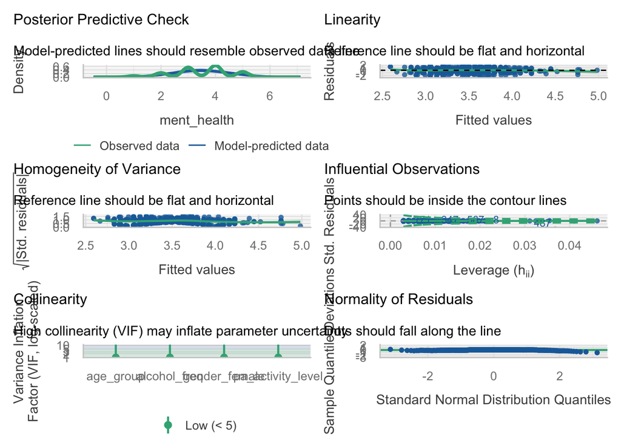

```r
performance::check_model(m3)
```

## Reportar resultados `report::report()`

```r
report::report(m3)
```

```
We fitted a linear model (estimated using OLS) to predict ment_health with
pa_activity_level, alcohol_freq, age_group and gender_female (formula:
ment_health ~ pa_activity_level + alcohol_freq + age_group + gender_female).
The model explains a statistically significant and moderate proportion of
variance (R2 = 0.13, F(4, 568) = 22.15, p < .001, adj. R2 = 0.13). The model's
intercept, corresponding to pa_activity_level = 0, alcohol_freq = 0, age_group
= 0 and gender_female = 0, is at 3.09 (95% CI [2.82, 3.37], t(568) = 22.12, p <
.001). Within this model:

  - The effect of pa activity level is statistically significant and positive
(beta = 0.24, 95% CI [0.11, 0.37], t(568) = 3.53, p < .001; Std. beta = 0.14,
95% CI [0.06, 0.22])
  - The effect of alcohol freq is statistically significant and negative (beta =
-0.07, 95% CI [-0.12, -0.03], t(568) = -3.12, p = 0.002; Std. beta = -0.12, 95%
CI [-0.20, -0.05])
  - The effect of age group is statistically significant and positive (beta =
0.30, 95% CI [0.21, 0.39], t(568) = 6.69, p < .001; Std. beta = 0.26, 95% CI
[0.18, 0.34])
  - The effect of gender female is statistically significant and negative (beta =
-0.43, 95% CI [-0.60, -0.25], t(568) = -4.84, p < .001; Std. beta = -0.19, 95%
CI [-0.27, -0.11])

Standardized parameters were obtained by fitting the model on a standardized
version of the dataset. 95% Confidence Intervals (CIs) and p-values were
computed using a Wald t-distribution approximation.
```

## Reportar resultados `report::report_effectsize()`

```r
report::report_effectsize(m3)
```

```
Effect sizes were labelled following Cohen's (1988) recommendations.

very small (Std. beta = 6.45e-16, 95% CI [-0.08, 0.08])
very small (Std. beta = 0.14, 95% CI [0.06, 0.22])
very small (Std. beta = -0.12, 95% CI [-0.20, -0.05])
small (Std. beta = 0.26, 95% CI [0.18, 0.34])
very small (Std. beta = -0.19, 95% CI [-0.27, -0.11])
```

```r
report::report_performance(m3)
```

```
The model explains a statistically significant and moderate proportion of
variance (R2 = 0.13, F(4, 568) = 22.15, p < .001, adj. R2 = 0.13)
```

## Visualizar resultados `sjPlot::plot_model()`

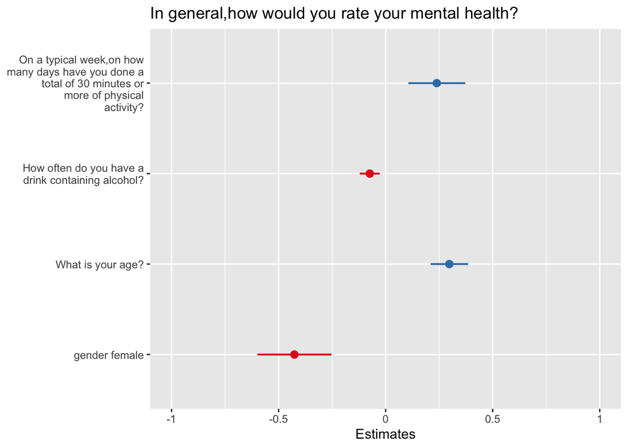

```r
sjPlot::plot_model(m3)
```

## Visualizar resultados `sjPlot::plot_model()` (adaptado)

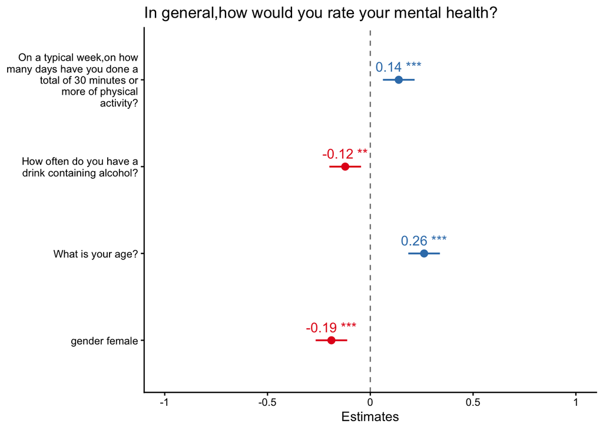

```r
sjPlot::plot_model(m3,
                   type = "std",
                   show.values = TRUE,
                   show.p = TRUE) +
  theme_classic() +
  geom_hline(yintercept = 0,
             linetype = 2,
             color = "gray50")
```

## Supuestos: casos con alta influencia `studentized residuals`

Observa si aparecen casos con residuos extremos, es decir, observaciones que el modelo predice especialmente mal.

```r
# Studentized residuals
car::outlierTest(model = m3)
```

```
No Studentized residuals with Bonferroni p < 0.05
Largest |rstudent|:
   rstudent unadjusted p-value Bonferroni p
8 -2.867531          0.0042907           NA
```

## Supuestos: casos con alta influencia `leverage`

Observa si hay casos con valores de *leverage* claramente superiores al promedio; estos casos tienen combinaciones poco habituales en las variables predictoras.

```r
# calcular los valores
hat <- hatvalues(model = m3)

# seleccionar los valores que están por encima de ese valor
hat[hat > mean(hat)*3]
```

```
        21         48        394        500        557        570
0.02953345 0.04612379 0.03108828 0.03550266 0.03243163 0.04104017
```

hatvalues: “high leverage is when the hat value is more than 2-3 times the mean” (Field, 2018)

## Supuestos: casos con alta influencia `Cook's distance`

Observa cuáles son los casos con mayor distancia de Cook; estos pueden tener un impacto importante sobre los coeficientes del modelo.

```r
cooksd <- cooks.distance(m3)

head(sort(cooksd, decreasing = TRUE))
```

```
         8        353        500        172        584        380
0.03582147 0.02079569 0.01926403 0.01683315 0.01588752 0.01516345
```

## Supuestos: casos con alta influencia `Cook's distance`

Observa si alguna observación destaca claramente por encima del resto; esto sugiere que podría estar influyendo de forma desproporcionada en el modelo.

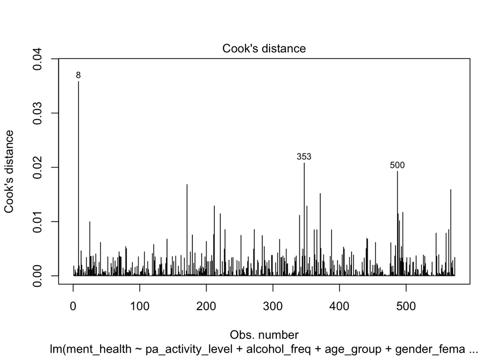

```r
# Visualizar la distancia de Cook
plot(x = m3, which = 4)
```

## Diagnósticos: Linealidad

Observa si los residuos se distribuyen de forma aleatoria alrededor de la línea horizontal; patrones claros pueden indicar problemas de linealidad.

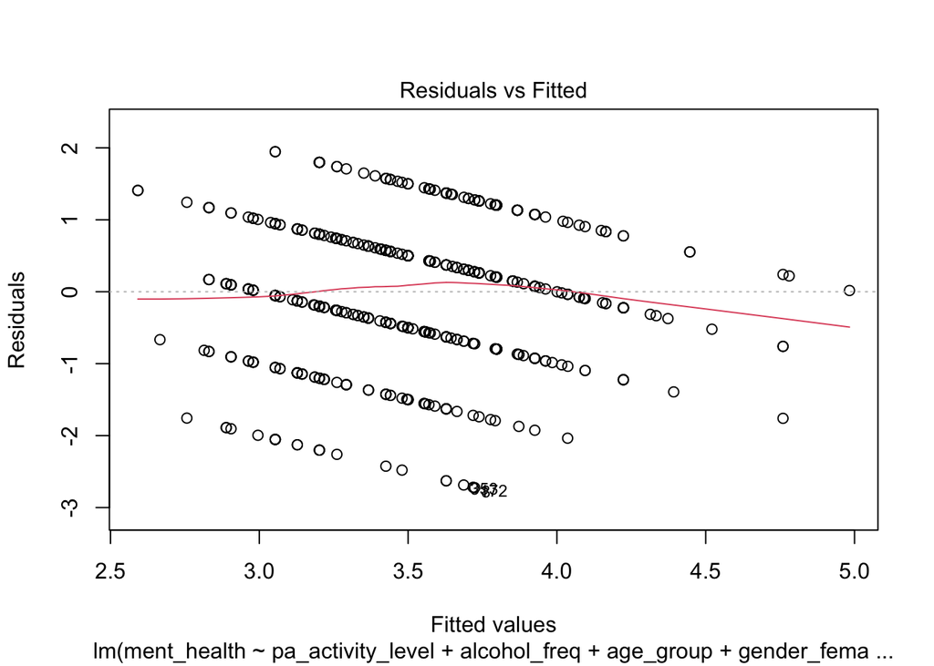

```r
# Linealidad de los parámetros
plot(x = m3, which = 1)
```

## Diagnósticos: Homogeneidad de la varianza

Observa si la dispersión de los residuos se mantiene relativamente constante; una forma de embudo puede indicar varianza no homogénea.

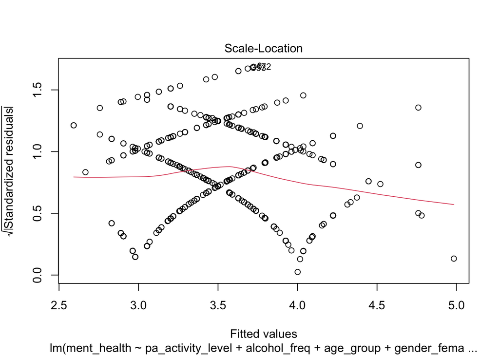

```r
# línea horizontal
plot(x = m3, which = 3)
```

## Diagnósticos: Residuos

Observa si hay casos con alta influencia combinando residuos grandes y valores altos de *leverage*.

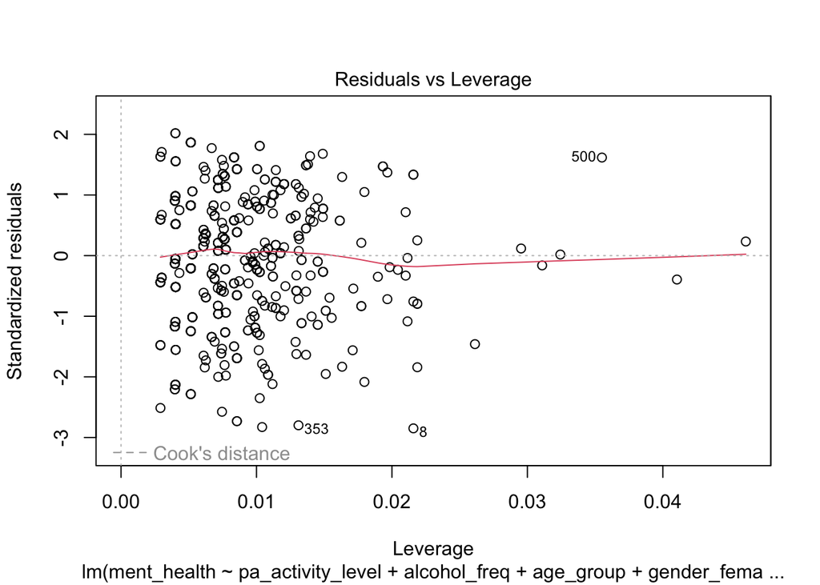

```r
# Residuals vs. Leverage
plot(x = m3, which = 5)
```

## Diagnósticos: Residuos

Observa si las relaciones entre los predictores y los residuos parecen aleatorias; patrones sistemáticos pueden sugerir que el modelo no captura bien la relación.

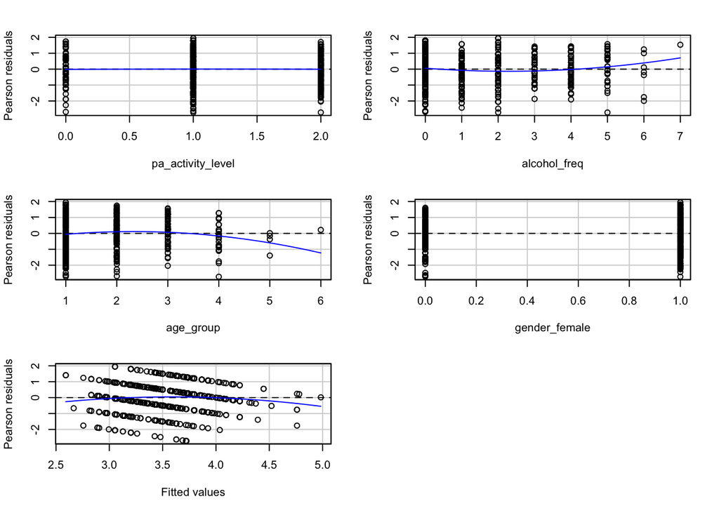

```
                  Test stat Pr(>|Test stat|)
pa_activity_level   -0.1576         0.874836
alcohol_freq         2.5041         0.012555 *
age_group           -2.8270         0.004864 **
gender_female        0.2789         0.780436
Tukey test          -1.6788         0.093185 .
---
Signif. codes:  0 '***' 0.001 '**' 0.01 '*' 0.05 '.' 0.1 ' ' 1
```

```r
car::residualPlots(m3)
```

## Diagnósticos: Normalidad de los Residuos

Observa si los puntos siguen aproximadamente la línea diagonal; desviaciones fuertes sugieren que los residuos se alejan de la normalidad.

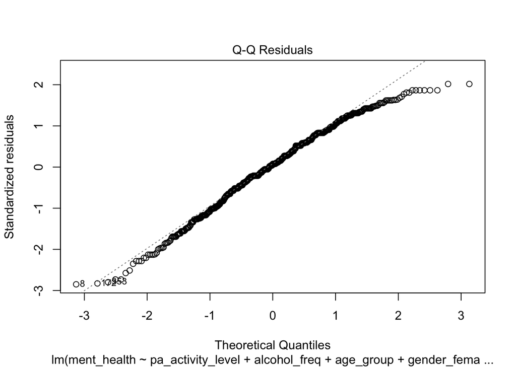

```r
plot(x = m3, which = 2)
```

## Diagnósticos: Normalidad de los Residuos

Observa si la distribución de los residuos tiene una forma aproximadamente simétrica y centrada alrededor de cero.

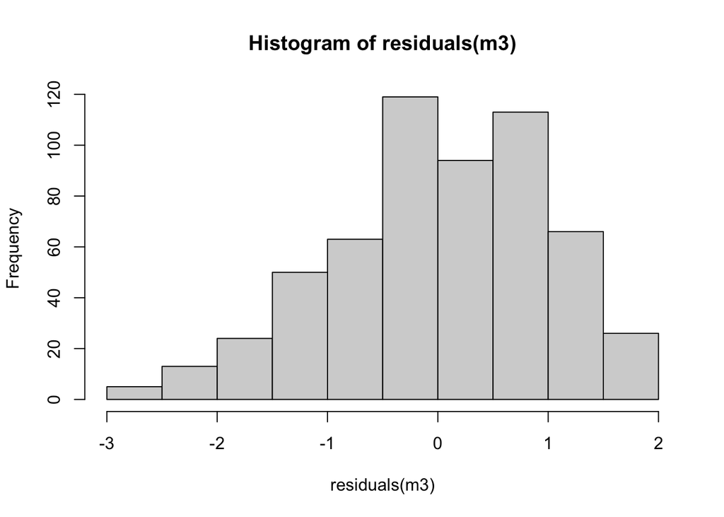

```r
hist(x = residuals(m3))
```

## Diagnósticos: Colinealidad (VIF)

Observa si los valores de VIF son elevados; valores altos sugieren que algunos predictores comparten demasiada información entre sí.

```r
# Colinealidad: VIF
car::vif(m3)
```

```
pa_activity_level      alcohol_freq         age_group     gender_female
         1.010667          1.006458          1.006020          1.001582
```

## Regresión con predictores dicotómicos

- Regresión con predictor dicotómico

```r
m4 <- lm(ment_health ~ gender_female, data = data)
parameters::parameters(m4)
```

```
Parameter     | Coefficient |   SE |         95% CI | t(571) |      p
---------------------------------------------------------------------
(Intercept)   |        3.79 | 0.08 | [ 3.64,  3.94] |  49.07 | < .001
gender female |       -0.44 | 0.09 | [-0.62, -0.26] |  -4.75 | < .001
```

- Diferencia de medias

```r
m5 <- t.test(ment_health ~ gender_female, data = data)
parameters::parameters(m5)
```

```
Welch Two Sample t-test

Parameter   |         Group | gender_female = 0 | gender_female = 1
-------------------------------------------------------------------
ment_health | gender_female |              3.79 |              3.35

Parameter   | Difference |       95% CI | t(325.61) |      p
------------------------------------------------------------
ment_health |       0.44 | [0.26, 0.62] |      4.74 | < .001

Alternative hypothesis: true difference in means between group 0 and group 1 is not equal to 0
```

# Ejercicio

## Ejercicio (20 minutos)

¿la salud mental auto-reportada se asocia con la etnia, el consumo de café y la calidad del sueño?

La variable dependiente será `ment_health`.

Los predictores principales serán:

```r
ethnicity_black # El grupo de referencia para etnia será `White`.
ethnicity_asian # El grupo de referencia para etnia será `White`.
caffeine_exam
sleep_quality
```

1. Explora descriptivamente las variables principales.
2. Comprueba que las variables dummy de etnia están correctamente codificadas (puedes usar `count()`)
3. Examina las asociaciones bivariadas entre salud mental, consumo de café y calidad del sueño.
4. Estima un modelo con etnia como predictor.
5. Estima un modelo **adicionando** consumo de café como predictor.
6. Estima un modelo **adicionando** calidad del sueño como predictor.
7. Estima un modelo controlando por `género` y `edad.`
8. Compara los modelos.
9. Diagnostica el modelo ajustado.
10. Visualiza los coeficientes del modelo ajustado.
11. Redacta una conclusión breve evitando interpretaciones causales fuertes.

### Reto adicional

Prueba si la calidad del sueño modera la relación entre consumo de café y salud mental.

# Soluciones

## Solución 1: explorar variables principales

### Qué deberían observar

- El número de casos válidos por variable.
- La presencia de valores perdidos.
- La media y desviación típica de las variables continuas.
- El rango de las variables.

### Interpretación esperada

Antes de estimar modelos, debemos comprobar que las variables tienen valores válidos, que no hay errores evidentes de codificación y que las variables continuas presentan variabilidad suficiente.

## Solución 2: comprobar las dummies de etnia

### Qué deberían observar

- Las personas clasificadas como `White` deberían tener:
  - `ethnicity_black = 0`
  - `ethnicity_asian = 0`
- Las personas clasificadas como `Black` deberían tener:
  - `ethnicity_black = 1`
  - `ethnicity_asian = 0`
- Las personas clasificadas como `Asian` deberían tener:
  - `ethnicity_black = 0`
  - `ethnicity_asian = 1`

### Interpretación esperada

El grupo `White` funciona como grupo de referencia. Por tanto, los coeficientes de `ethnicity_black` y `ethnicity_asian` indican diferencias promedio respecto al grupo `White`.

## Solución 3: asociaciones bivariadas

### Qué deberían observar

- La dirección de la asociación entre `caffeine_exam` y `ment_health`.
- La dirección de la asociación entre `sleep_quality` y `ment_health`.
- La fuerza relativa de ambas asociaciones.

## Solución 3: asociaciones bivariadas

### Qué deberían observar

- Si las relaciones parecen aproximadamente lineales.
- Si hay posibles casos extremos o distribuciones extrañas

### Interpretación esperada

Las correlaciones permiten una primera aproximación descriptiva, pero no controlan por otras variables. Por eso, después estimamos modelos de regresión múltiple.

## Solución 4: modelo con etnia

### Interpretación de los coeficientes

- El intercepto representa el valor esperado de `ment_health` para el grupo `White`.
- El coeficiente de `ethnicity_black` representa la diferencia promedio entre el grupo `Black` y el grupo `White`.
- El coeficiente de `ethnicity_asian` representa la diferencia promedio entre el grupo `Asian` y el grupo `White`.

### Ejemplo de redacción

El modelo estimó diferencias en salud mental según etnia, usando el grupo White como referencia. Los coeficientes de `ethnicity_black` y `ethnicity_asian` indican si estos grupos presentan valores promedio de salud mental más altos o más bajos que el grupo White.

## Solución 5: modelo con consumo de café

### Interpretación de los coeficientes

- El intercepto representa el valor esperado de `ment_health` cuando `caffeine_exam = 0`.
- El coeficiente de `caffeine_exam` indica cuánto cambia `ment_health` por cada unidad adicional de consumo de café.

### Ejemplo de redacción

El modelo estima la asociación entre consumo de café y salud mental. Un coeficiente negativo indicaría que un mayor consumo de café se asocia con valores más bajos en salud mental.

## Solución 6: modelo con calidad del sueño

### Interpretación de los coeficientes

- El intercepto representa el valor esperado de `ment_health` cuando `sleep_quality = 0`.
- El coeficiente de `sleep_quality` indica cuánto cambia `ment_health` por cada unidad adicional de calidad del sueño.

### Qué deberían comparar

- Si los coeficientes de etnia cambian respecto al modelo simple.
- Si el coeficiente de café cambia al incluir calidad del sueño.
- Si el coeficiente de sueño se mantiene al controlar por café y etnia.
- Qué predictores siguen siendo estadísticamente significativos.

### Ejemplo de redacción

Al incluir etnia, consumo de café y calidad del sueño en el mismo modelo, cada coeficiente representa la asociación única de ese predictor con salud mental, controlando por los demás predictores del modelo.

## Solución 7: modelo ajustado por covariables

### Qué deberían observar

- Si los coeficientes principales cambian al añadir `gender_female` y `age_group`.
- Si algunos predictores dejan de ser significativos.
- Si el modelo ajustado permite una interpretación más completa.

### Ejemplo de redacción

Después de ajustar por género y edad, el modelo permite estimar la asociación entre los predictores principales y salud mental manteniendo constantes estas covariables sociodemográficas.

## Solución 8: comparación de modelos

## Solución 8: comparación de modelos

### Qué deberían observar

- Qué modelo tiene mayor `R2`.
- Qué modelo tiene mejor AIC/BIC.
- Si el modelo ajustado mejora respecto a los modelos simples.
- Si algunos coeficientes cambian notablemente entre modelos.

### Interpretación esperada

Un modelo con más predictores suele explicar más varianza, pero eso no significa automáticamente que sea mejor. La comparación debe considerar el ajuste, la parsimonia y la interpretación teórica.

## Solución 10: diagnóstico del modelo ajustado

## Solución 10: diagnóstico del modelo ajustado

### Qué deberían observar

- Si los residuos se distribuyen de forma aproximadamente normal.
- Si hay problemas de heterocedasticidad.
- Si hay casos influyentes.
- Si los valores de VIF sugieren colinealidad problemática (VIF > 10).

### Interpretación esperada

El diagnóstico permite evaluar si el modelo cumple razonablemente los supuestos de regresión lineal. Si hay problemas graves, los resultados deben interpretarse con cautela o modificar el modelo.

## Solución 11: visualización de coeficientes

### Qué deberían observar

- Qué predictor tiene el coeficiente más grande.
- Qué predictores tienen intervalos que cruzan cero.
- Qué variables parecen tener asociaciones más consistentes con salud mental.

## Solución 12: reporte automático (orientativo)

### Ejemplo de redacción general

Se estimó un modelo de regresión lineal para analizar si la salud mental auto-reportada se asociaba con etnia, consumo de café y calidad del sueño, ajustando por género y edad. Los resultados indican que algunos predictores se asociaron con la salud mental incluso después de controlar por las covariables incluidas en el modelo. En particular, los coeficientes permiten identificar qué variables se relacionan con valores más altos o más bajos en salud mental. Sin embargo, dado que se trata de un análisis observacional y transversal, los resultados deben interpretarse como asociaciones y no como evidencia causal.

# Reto adicional

## Solución reto: interacción entre café y sueño

## Solución reto: interacción entre café y sueño

### Interpretación esperada

El término de interacción `caffeine_exam:sleep_quality` indica si la asociación entre consumo de café y salud mental cambia en función de la calidad del sueño.

### Cómo interpretar

- Si la interacción no es significativa, no hay evidencia clara de que la relación entre café y salud mental dependa de la calidad del sueño.
- Si la interacción es significativa, la asociación entre café y salud mental varía según los niveles de calidad del sueño.
- El gráfico de interacción ayuda a visualizar si la pendiente de café cambia cuando la calidad del sueño es baja, media o alta.

## Resumen de la sesión: regresión lineal

### Ideas centrales

- La regresión lineal permite examinar cómo una variable resultado se asocia con una o más variables predictoras.
- El modelo resume una relación compleja mediante una estimación simple y útil.
- Los coeficientes indican la dirección y magnitud de la asociación entre cada predictor y el resultado.
- En modelos múltiples, cada predictor se interpreta manteniendo constantes las demás variables.
- La regresión ayuda a controlar explicaciones alternativas, pero no demuestra causalidad por sí sola.

### Buenas prácticas

- Explorar los datos antes de estimar el modelo.
- Comparar modelos simples, múltiples y ajustados.
- Evaluar el ajuste global del modelo, no solo los coeficientes individuales.
- Revisar los diagnósticos: residuos, linealidad, varianza, colinealidad y casos influyentes.
- Comunicar los resultados como asociaciones cuando el diseño no permite inferencias causales fuertes.

**TipImportante**

La regresión lineal no es solo una técnica para obtener coeficientes: es una herramienta para construir, comparar, diagnosticar e interpretar modelos de forma teóricamente informada y empíricamente cuidadosa.